# Calculation of dominant wavelength

B Steele

2023-06-20

# Purpose

This script calculates dominant wavelength (dWL) for Loch and Sky Ponds using median Rrs values for the RGB bands from Landsat Collection 2 Surface Reflectance Product and test for any historical trend in the data.

### Methods

# Calculate dWL from Rrs values

Calculate Forel-Ule index for unscaled Rrs data.

```r
# this is attributed to from https://github.com/GlobalHydrologyLab/LakeReflectanceRepo/blob/master/00_Functions.R
fui.hue <- function(R, G, B) {

  # Convert R,G, and B spectral reflectance to dominant wavelength based
  # on CIE chromaticity color space

  # see Wang et al 2015. MODIS-Based Radiometric Color Extraction and
  # Classification of Inland Water With the Forel-Ule
  # Scale: A Case Study of Lake Taihu

  require(colorscience)
  # chromaticity.diagram.color.fill()
  Xi <- 2.7689*R + 1.7517*G + 1.1302*B
  Yi <- 1.0000*R + 4.5907*G + 0.0601*B
  Zi <- 0.0565*G + 5.5943*B

  # calculate coordinates on chromaticity diagram
  x <-  Xi / (Xi + Yi +  Zi)
  y <-  Yi / (Xi + Yi +  Zi)
  z <-  Zi / (Xi + Yi +  Zi)

  # calculate hue angle
  alpha <- atan2((x - 0.33), (y - 0.33)) * 180/pi

  # make look up table for hue angle to wavelength conversion
  cie <- cccie31 %>%
    mutate(a = atan2( (x - 0.33), (y - 0.33)) * 180/pi) %>%
    dplyr::filter(wlnm <= 700) %>%
    dplyr::filter(wlnm >=380)

  # find nearest dominant wavelength to hue angle
  wl <- cie[as.vector(sapply(alpha,function(x) which.min(abs(x - cie$a)))), 'wlnm']

  #out <- cbind(as.data.frame(alpha), as.data.frame(wl))

  return(wl)
}

## Code for connnecting dWL to forel-ule index
fui.lookup <- tibble(dWL = c(471:583), fui = NA)

fui.lookup$fui[fui.lookup$dWL <= 583] = 21
fui.lookup$fui[fui.lookup$dWL <= 581] = 20
fui.lookup$fui[fui.lookup$dWL <= 579] = 19
fui.lookup$fui[fui.lookup$dWL <= 577] = 18
fui.lookup$fui[fui.lookup$dWL <= 575] = 17
fui.lookup$fui[fui.lookup$dWL <= 573] = 16
fui.lookup$fui[fui.lookup$dWL <= 571] = 15
fui.lookup$fui[fui.lookup$dWL <= 570] = 14
fui.lookup$fui[fui.lookup$dWL <= 569] = 13
fui.lookup$fui[fui.lookup$dWL <= 568] = 12
fui.lookup$fui[fui.lookup$dWL <= 567] = 11
fui.lookup$fui[fui.lookup$dWL <= 564] = 10
fui.lookup$fui[fui.lookup$dWL <= 559] = 9
fui.lookup$fui[fui.lookup$dWL <= 549] = 8
fui.lookup$fui[fui.lookup$dWL <= 530] = 7
fui.lookup$fui[fui.lookup$dWL <= 509] = 6
fui.lookup$fui[fui.lookup$dWL <= 495] = 5
fui.lookup$fui[fui.lookup$dWL <= 489] = 4
fui.lookup$fui[fui.lookup$dWL <= 485] = 3
fui.lookup$fui[fui.lookup$dWL <= 480] = 2
fui.lookup$fui[fui.lookup$dWL <= 475 & fui.lookup$dWL >470] = 1
```

## Apply dWL calculation to Sky/Loch data

```r
ls <- ls %>%
  mutate(dWL = fui.hue(med_Red_corr, med_Green_corr, med_Blue_corr))
```

# Quick visualization of dWL over time

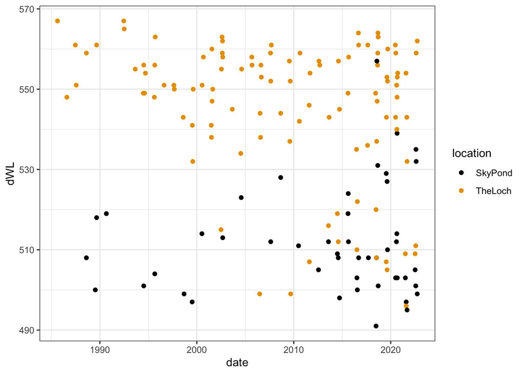

There is certainly an increase in variability in dWL at The Loch. Sky Pond does not have enough data prior to 2010 to really assess much from the remote sensing record.

## Check to see if there is a trend in the The Loch

Using Sen’s method for computing slope on a timeseries, see if there is a statistically significant trend in the data. Because the Sky Pond data are pretty sparse, we’ll have to do this with Loch only. First, we need a complete timeseries with a static time step. The smallest complete, static, time step is one year, so we’ll summarize dWL for that timestep.

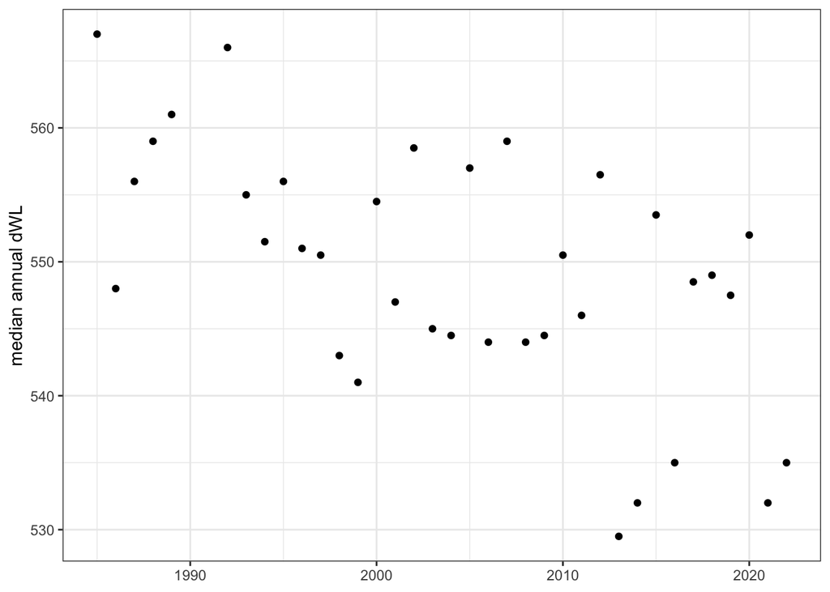

```r
Loch_annual = ls_gt0 %>%
  filter(location == 'TheLoch') %>%
  mutate(year = as.numeric(format(date, '%Y'))) %>%
  group_by(year) %>%
  dplyr::summarize(med_dWL = median(dWL))

ggplot(Loch_annual, aes(x = year, y = med_dWL)) +
  geom_point() +
  labs(x = NULL,
       y = 'median annual dWL') +
  theme_bw()
```

There are some gaps in the complete record, so we’ll only use data form 1992 forward (where there are no gaps in the timeseries) and test for trends.

### Check for autocorrelation.

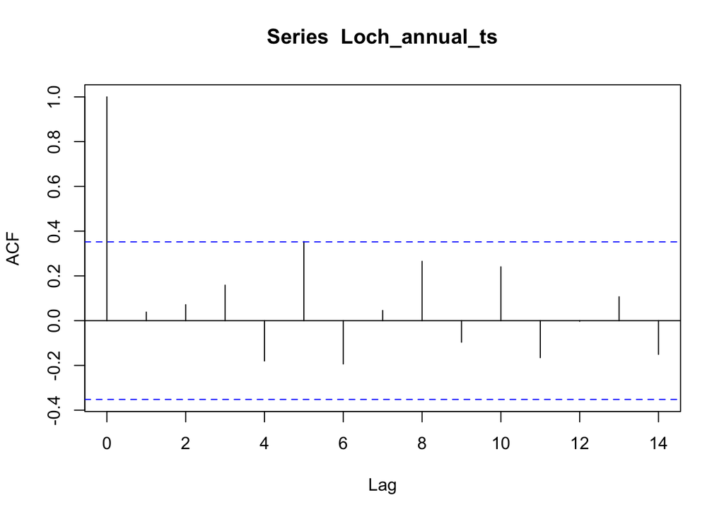

There is no strong evidence of autocorrelation in this dataset. Looks like 5-year lag has some autocorrelation, but it is barely beyond the boundary of ‘random chance’.

### Check for trend

We’ll now use Mann-Kendall test to see if a slope is detected in this timeseries.

```
##
##  Mann-Kendall trend test
##
## data:  Loch_annual_ts
## z = -2.2281, n = 31, p-value = 0.02587
## alternative hypothesis: true S is not equal to 0
## sample estimates:
##            S         varS          tau
## -132.0000000 3456.6666667   -0.2854096
```

The Loch annual timeseries of dWL does exhibit a negative slope according to MK (S = -132, p-value <0.05, z = -2.22, n = 31).

### Calculate Sen’s slope

And now, we can estimate the rate of change by calculating the Sen’s slope.

```
##
##  Sen's slope
##
## data:  Loch_annual_ts
## z = -2.2281, n = 31, p-value = 0.02587
## alternative hypothesis: true z is not equal to 0
## 95 percent confidence interval:
##  -0.77272727 -0.07142857
## sample estimates:
## Sen's slope
##        -0.5
```

Per the Sen method for testing rate of change (aka slope), we can assert that there is a decreasing trend of approximetely -0.5 dWL per year (-0.7727273 < dWL < -0.0714286) in dWL since 1992 (p < 0.05, z = -2.2281, n = 31).